# Example Strange Dynamics

M. Jan, P. Franken

2023-03-14

Shows genes with well known dynamics like Bmal1 (Arntl) in the liver following a circadian dynamics (as a sine-wave). Or Homer1 following sleep-wake distribution (as a process-S of sleep).

Shows also genes with stranger dynamics that we originally could not explain using sine-wave or a process-S

# LIBS

```r
library(patchwork)
```

```r
source("../FileLocation.R")
source(RASTERPLOT_FUN)
source(TEMPLATE_FUN)
source(COLORFUN)
source(GENERAL_FUN)
colorCode<-ColorCode()
```

# Plot data

Load dataset in mouse

```r
dataMouseCortex<-LOADMOUSE(Tissue="Cortex")
dataMouseLiver<-LOADMOUSE(Tissue="Liver")
```

A function to add a straight line between time-points, baseline is replicated

```r
AddFitMouse<-function(Gene,dataMouse){
  fitBSL<-MeanBSLfit(dataMouse$rna_expr,Gene,bsl = 48)
  fitRec<-MeanBSLfit(dataMouse$rna_expr,Gene,bsl = 222)
  fitBSL_rep<-MeanBSLfit_Rep(dataMouse$rna_expr,Gene,bsl = 48)
  addfits<-list(fitBSL,fitBSL_rep,fitRec)
  return(addfits)
}
colorf<-c("black","grey25","black");ltys<-c("solid","42","solid")
```

Shows Homer1, Bmal1 and Acot11

```r
Homer1_c<-RasterPlot(ProbeGene = "Homer1",Dataset = "Cortex",DaysShows = c(2,3,4,5,10),MeanPointSize = 3,npretty = 2,ModelFitLine = 0,
                    AddFits = AddFitMouse("Homer1",dataMouseCortex),ColsAddFits = colorf,LtyAddFits = ltys,AddSleepWake = T)
```

```
## L'objet suivant est masqué _par_ '.GlobalEnv':
##
##     .pt
```

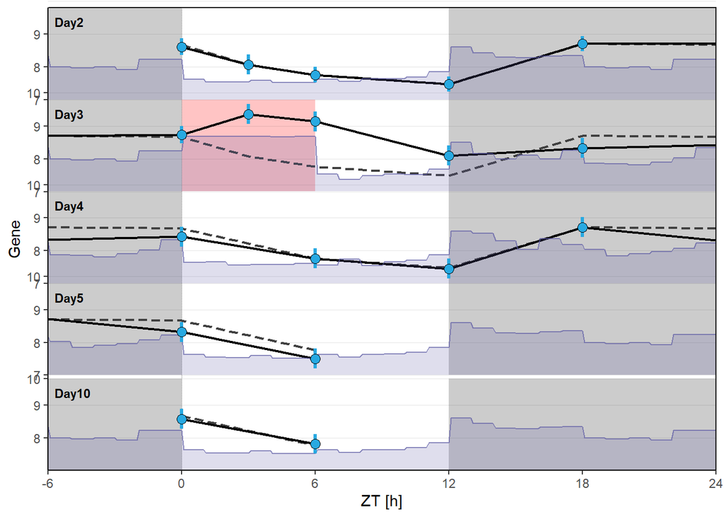

```r
Homer1_c
```

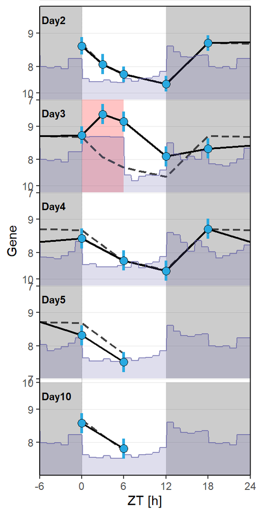

```r
Homer1_c<-RasterPlot(ProbeGene = "Homer1",Dataset = "Cortex",DaysShows = c(2,3,4,5,10),MeanPointSize = 3,npretty = 2,ModelFitLine = 0,
                    AddFits = AddFitMouse("Homer1",dataMouseCortex),ColsAddFits = colorf,LtyAddFits = ltys,AddSleepWake = T)
Homer1_c
```

[figure not shown]

```r
pbmal_c<-RasterPlot(ProbeGene = "Arntl",Dataset = "Cortex",DaysShows = c(2,3,4,5,10),MeanPointSize = 3,npretty = 2,ModelFitLine = 0,
                    AddFits = AddFitMouse("Arntl",dataMouseCortex),ColsAddFits = colorf,LtyAddFits = ltys,AddSleepWake = T)
pbmal_c
```

[figure not shown]

```r
pbmal_l<-RasterPlot(ProbeGene = "Arntl",Dataset = "Liver",DaysShows = c(2,3,4,5,10),MeanPointSize = 3,npretty = 2,ModelFitLine = 0,
                    AddFits = AddFitMouse("Arntl",dataMouseLiver),ColsAddFits = colorf,LtyAddFits = ltys,AddSleepWake = T)
pbmal_l
```

[figure not shown]

```r
pacot_c<-RasterPlot(ProbeGene = "Acot11",Dataset = "Cortex",DaysShows = c(2,3,4,5,10),MeanPointSize = 3,npretty = 2,ModelFitLine = 0,
                    AddFits = AddFitMouse("Acot11",dataMouseCortex),ColsAddFits = colorf,LtyAddFits = ltys,AddSleepWake = T)
pacot_c
```

Shows NCOR1 in human that decrease expression when sleeping in anti-phase, and decrease expression when awake during contant routine.

Load data

```r
dataHuman<-LOADHUMAN()
```

Function to add straight line between time-point in human

```r
AddFitHuman<-function(Gene,dataHumanExpr,EvalTime=NULL){
  fitBSL<-MeanBSLfit_Rep(dataHuman$HT_Desync,Gene,bsl = 67,EvalTime)
  fitRec<-MeanBSLfit(dataHumanExpr,Gene,bsl = 1e5)
  addfits<-list(fitBSL,fitRec)
  return(addfits)
}
```

```r
pncor1_sync<-RasterPlot(ProbeGene = "A_24_P204214",Dataset = "Desync",DaysShows = c(3),MeanPointSize = 3,npretty = 2,ModelFitLine = 0,ReplicatesSamples = T,PreviousHourShow = 12,ylim=c(11.3,12.5),
                          AddFits = AddFitHuman("A_24_P204214",dataHuman$HT_Desync),ColsAddFits = c(rgb(0,0,0,0),"black"),LtyAddFits = c("42","solid"),AddSleepWake = T)+theme(plot.margin = margin(0,45,0,0))
pncor1_desync<-RasterPlot(ProbeGene = "A_24_P204214",Dataset = "Desync",DaysShows = c(6),MeanPointSize = 3,npretty = 2,ModelFitLine = 0,ReplicatesSamples = T,PreviousHourShow = 12,ylim=c(11.3,12.5),
                          AddFits = AddFitHuman("A_24_P204214",dataHuman$HT_Desync),ColsAddFits = c("grey25","black"),LtyAddFits = c("42","solid"),AddSleepWake = T)+
  theme(plot.margin = margin(0,45,0,0))
pncor1_ctr<-RasterPlot(ProbeGene = "A_24_P204214",Dataset = "Ctr",DaysShows = c(10),MeanPointSize = 3,npretty = 2,ModelFitLine = 0,ReplicatesSamples = T,PreviousHourShow = 12,ylim=c(11.3,12.5),
                          AddFits = AddFitHuman("A_24_P204214",dataHuman$HT_Ext,EvalTime = seq(208,235,by=4)),ColsAddFits = c("grey25","black"),LtyAddFits = c("42","solid"),AddSleepWake = T)+theme(plot.margin = margin(0,45,0,0))
```

```
## [1] 10
```

```r
pncor1_res<-RasterPlot(ProbeGene = "A_24_P204214",Dataset = "Res",DaysShows = c(10),MeanPointSize = 3,npretty = 2,ModelFitLine = 0,ReplicatesSamples = T,PreviousHourShow = 12,ylim=c(11.3,12.5),
                          AddFits = AddFitHuman("A_24_P204214",dataHuman$HT_Res,EvalTime = seq(208,235,by=4)),ColsAddFits = c("grey25","black"),LtyAddFits = c("42","solid"),AddSleepWake = T)+theme(plot.margin = margin(0,45,0,0))
```

```
## [1] 10
```

[figure not shown]

```r
pncor1_sync<-RemoveXaxis(pncor1_sync)
pncor1_desync<-RemoveXaxis(pncor1_desync)
pncor1_desync<-RemoveYlab(pncor1_desync)
pncor1_ctr<-RemoveXaxis(pncor1_ctr)
pncor1_ctr<-RemoveYlab(pncor1_ctr)
pncor1_res<-RemoveYlab(pncor1_res)

pncor1_sync<-pncor1_sync+annotate("line",x=c(26,26),y=c(-3,-2),size=1,color="red",linetype="solid")
pncor1_sync<-pncor1_sync+annotate("text",label="FD in-\nphase",x=27,y=-2.5,hjust=0,color="red",fontface = "bold")
pncor1_desync<-pncor1_desync+annotate("line",x=c(26,26),y=c(-6,-5),size=1,color="red",linetype="solid")
pncor1_desync<-pncor1_desync+annotate("text",label="FD anti-\nphase",x=27,y=-5.5,hjust=0,color="red",fontface = "bold")

pncor1_ctr<-pncor1_ctr+annotate("line",x=c(26,26),y=c(-10,-9),size=1,color="red",linetype="solid")
pncor1_ctr<-pncor1_ctr+annotate("text",label="10h sleep +\nCR",x=27,y=-9.5,hjust=0,color="red",fontface = "bold")
pncor1_res<-pncor1_res+annotate("line",x=c(26,26),y=c(-10,-9),size=1,color="red",linetype="solid")
pncor1_res<-pncor1_res+annotate("text",label="6h sleep +\nCR",x=27,y=-9.5,hjust=0,color="red",fontface = "bold")

(pncor1_sync/pncor1_desync/pncor1_ctr/pncor1_res)+plot_layout(heights  = c(1,1,1,1))
```

[figure not shown]

```r
Homer1_c<-RemoveYlab(Homer1_c)+ggtitle(substitute(paste(italic("Homer1")," - Cortex")))
pbmal_c<-RemoveYlab(pbmal_c)+ggtitle(substitute(paste(italic("Bmal1")," - Cortex")))
pbmal_l<-RemoveYlab(pbmal_l)+ggtitle(substitute(paste(italic("Bmal1")," - Liver")))
pacot_c<-RemoveYlab(pacot_c)+ggtitle(substitute(paste(italic("Acot11")," - Liver")))
pncor1_sync<-RemoveYlab(pncor1_sync)+ggtitle(substitute(paste(italic("NCOR1")," - Blood")))


Homer1_c<-Homer1_c+ theme(axis.text = element_text(size = 12),axis.title = element_text(size = 12))
pbmal_c<-pbmal_c+ theme(axis.text = element_text(size = 12),axis.title = element_text(size = 12))
pbmal_l<-pbmal_l+ theme(axis.text = element_text(size = 12),axis.title = element_text(size = 12))
pacot_c<-pacot_c+ theme(axis.text = element_text(size = 12),axis.title = element_text(size = 12))
pncor1_sync<-pncor1_sync+ theme(axis.text = element_text(size = 12),axis.title = element_text(size = 12))
pncor1_desync<-pncor1_desync+ theme(axis.text = element_text(size = 12),axis.title = element_text(size = 12))
pncor1_ctr<-pncor1_ctr+ theme(axis.text = element_text(size = 12),axis.title = element_text(size = 12))
pncor1_res<-pncor1_res+ theme(axis.text = element_text(size = 12),axis.title = element_text(size = 12))


ggF<-Homer1_c|pbmal_l|pbmal_c|pacot_c|(pncor1_sync/pncor1_desync/pncor1_ctr/pncor1_res)
ggF
```

```r
ggsave(paste(FIGUREDIR,"ExampleGeneExpression.pdf",sep=""), width = 200*1.2, height = 150*1.2, units = "mm",plot = ggF)
```

# Plot data with fits

Now we plot the same genes with fits (black line) with sleep-wake response and circadian response on the oscillator

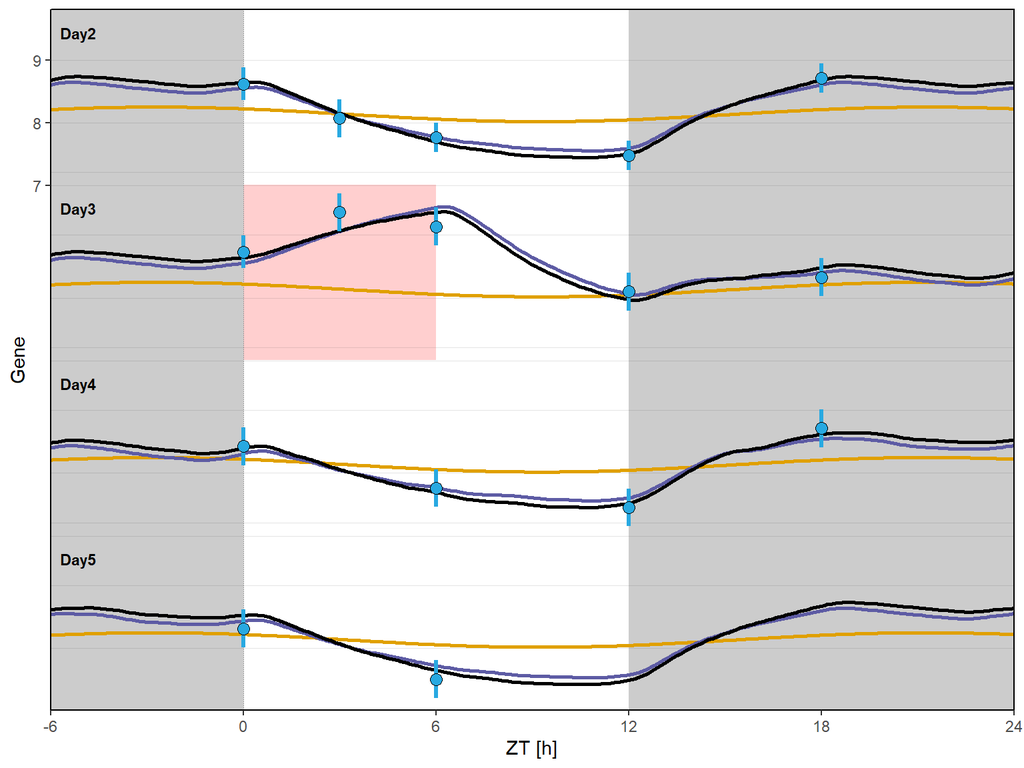

```r
homer1_c<-RasterPlot(ProbeGene = "Homer1",Dataset = "Cortex",DaysShows = c(2,3,4,5),MeanPointSize = 3,npretty = 2,ModelFitLine = 1,BSL_RepLine = 0,AddASkeldonSol = T,AddLowerUpperEquilibrium = F)
homer1_c
```

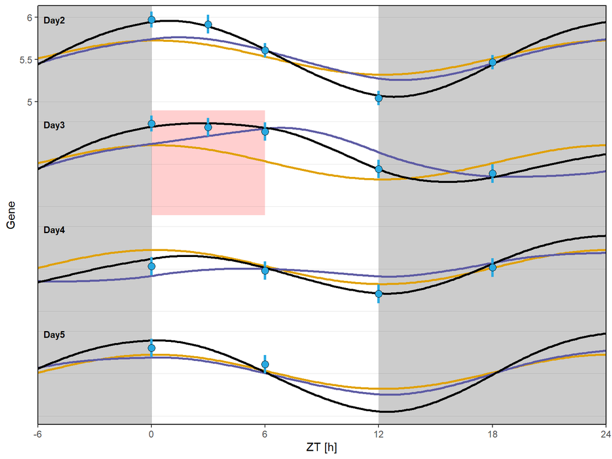

```r
pbmal_c<-RasterPlot(ProbeGene = "Arntl",Dataset = "Cortex",DaysShows = c(2,3,4,5),MeanPointSize = 3,npretty = 2,ModelFitLine = 1,BSL_RepLine = 0,AddASkeldonSol = T,AddLowerUpperEquilibrium = F)
pbmal_c
```

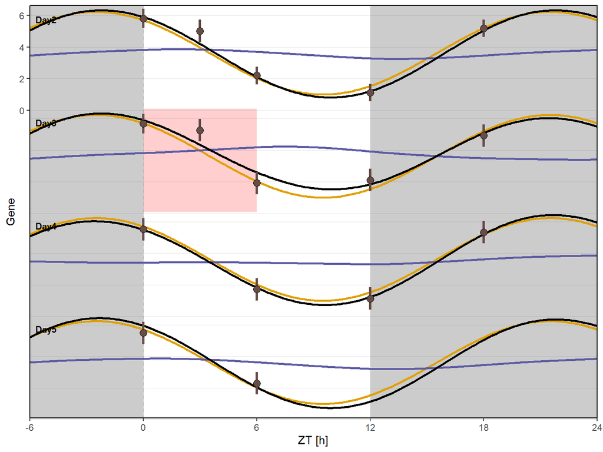

```r
pbmal_l<-RasterPlot(ProbeGene = "Arntl",Dataset = "Liver",DaysShows = c(2,3,4,5),MeanPointSize = 3,npretty = 2,ModelFitLine = 1,BSL_RepLine = 0,AddASkeldonSol = T,AddLowerUpperEquilibrium = F)
pbmal_l
```

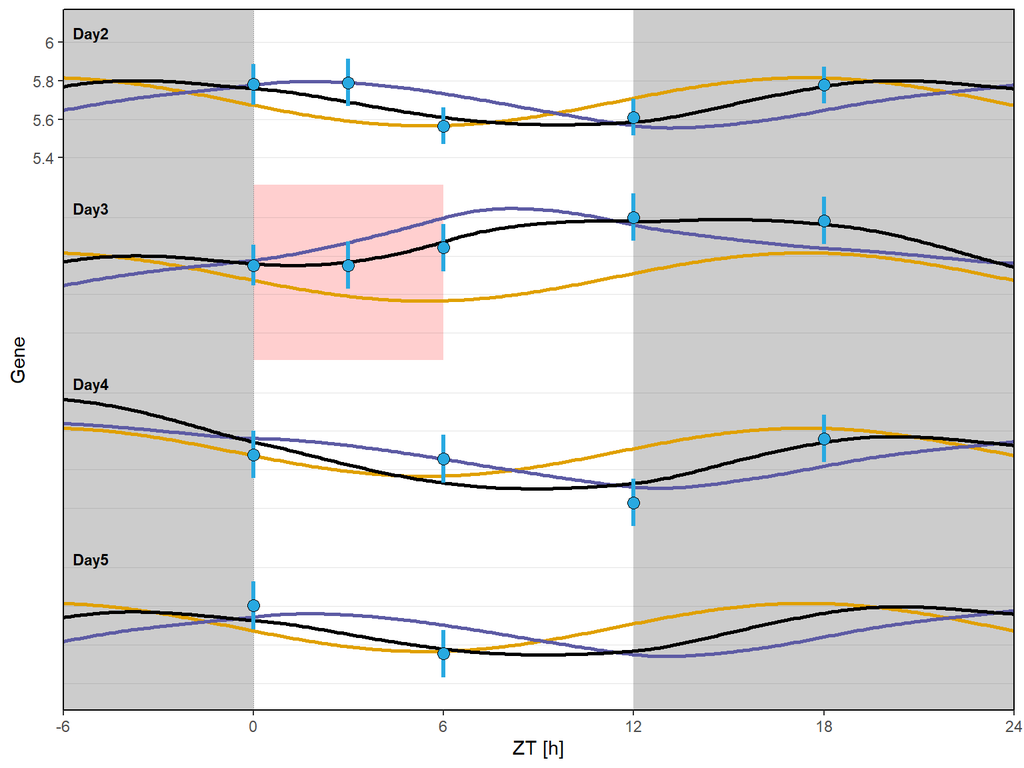

```r
pacot_c<-RasterPlot(ProbeGene = "Acot11",Dataset = "Cortex",DaysShows = c(2,3,4,5),MeanPointSize = 3,npretty = 2,ModelFitLine = 1,BSL_RepLine = 0,AddASkeldonSol = T,AddLowerUpperEquilibrium = F)
pacot_c
```

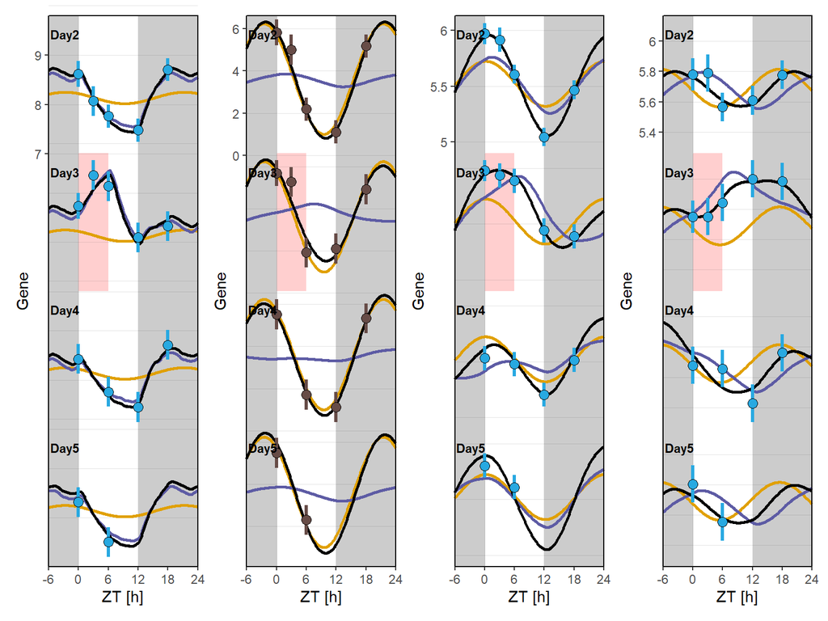

```r
homer1_c | pbmal_l| pbmal_c | pacot_c
```

Ncor1

```r
# AddFits = AddFitMouse("Arntl",dataMouseCortex),ColsAddFits = colorf,LtyAddFits = ltys
pncor1_sync<-RasterPlot(ProbeGene = "A_24_P204214",Dataset = "Desync",DaysShows = c(3),MeanPointSize = 3,npretty = 2,ModelFitLine = 1,ReplicatesSamples = T,PreviousHourShow = 12,ylim=c(11.3,12.5),BSL_RepLine = 0,AddASkeldonSol = T)+theme(plot.margin = margin(0,45,0,0))
pncor1_desync<-RasterPlot(ProbeGene = "A_24_P204214",Dataset = "Desync",DaysShows = c(6),MeanPointSize = 3,npretty = 2,ModelFitLine = 1,ReplicatesSamples = T,PreviousHourShow = 12,ylim=c(11.3,12.5),BSL_RepLine = 0,AddASkeldonSol = T)+
  theme(plot.margin = margin(0,45,0,0))
pncor1_ctr<-RasterPlot(ProbeGene = "A_24_P204214",Dataset = "Ctr",DaysShows = c(10),MeanPointSize = 3,npretty = 2,ModelFitLine = 1,ReplicatesSamples = T,PreviousHourShow = 12,ylim=c(11.3,12.5),BSL_RepLine = 0,AddASkeldonSol = T)+theme(plot.margin = margin(0,45,0,0))
```

```
## [1] 10
```

```r
pncor1_res<-RasterPlot(ProbeGene = "A_24_P204214",Dataset = "Res",DaysShows = c(10),MeanPointSize = 3,npretty = 2,ModelFitLine = 1,ReplicatesSamples = T,PreviousHourShow = 12,ylim=c(11.3,12.5),BSL_RepLine = 0,AddASkeldonSol = T)+theme(plot.margin = margin(0,45,0,0))
```

```
## [1] 10
```

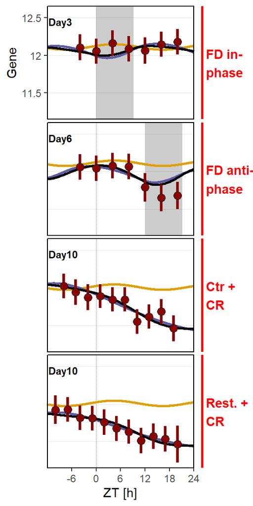

```r
pncor1_sync<-RemoveXaxis(pncor1_sync)
pncor1_desync<-RemoveXaxis(pncor1_desync)
pncor1_desync<-RemoveYaxis(pncor1_desync)
pncor1_ctr<-RemoveXaxis(pncor1_ctr)
pncor1_ctr<-RemoveYaxis(pncor1_ctr)
pncor1_res<-RemoveYaxis(pncor1_res)

pncor1_sync<-pncor1_sync+annotate("line",x=c(26,26),y=c(-3,-2),size=1,color="red",linetype="solid")
pncor1_sync<-pncor1_sync+annotate("text",label="FD in-\nphase",x=27,y=-2.5,hjust=0,color="red",fontface = "bold")
pncor1_desync<-pncor1_desync+annotate("line",x=c(26,26),y=c(-6,-5),size=1,color="red",linetype="solid")
pncor1_desync<-pncor1_desync+annotate("text",label="FD anti-\nphase",x=27,y=-5.5,hjust=0,color="red",fontface = "bold")

pncor1_ctr<-pncor1_ctr+annotate("line",x=c(26,26),y=c(-10,-9),size=1,color="red",linetype="solid")
pncor1_ctr<-pncor1_ctr+annotate("text",label="Ctr +\nCR",x=27,y=-9.5,hjust=0,color="red",fontface = "bold")
pncor1_res<-pncor1_res+annotate("line",x=c(26,26),y=c(-10,-9),size=1,color="red",linetype="solid")
pncor1_res<-pncor1_res+annotate("text",label="Rest. +\nCR",x=27,y=-9.5,hjust=0,color="red",fontface = "bold")

(pncor1_sync/pncor1_desync/pncor1_ctr/pncor1_res)+plot_layout(heights  = c(1,1,1,1))
```

Get SWrc

```r
swdmr_c<-SWDMr(dataMouseCortex$SWdf,dataMouseCortex$rna_expr)
fits_c<-read.table(CORTEXFITS,header=T)
SWrc_homer1c<-round(GetSWrcMouse("Homer1",swdmr_c,fits_c),2)
SWrc_pbmal_c<-round(GetSWrcMouse("Arntl",swdmr_c,fits_c),2)
SWrc_pacot_c<-round(GetSWrcMouse("Acot11",swdmr_c,fits_c),2)

swdmr_l<-SWDMr(dataMouseLiver$SWdf,dataMouseLiver$rna_expr)
fits_l<-read.table(LIVERFITS,header=T)
SWrc_pbmal_l<-round(GetSWrcMouse("Arntl",swdmr_l,fits_l),2)

fits_h<-read.table(HUMANFITS,header=T)
SWrc_NCOR1<-round(GetSWrcHuman("A_24_P204214",dataHuman$MeanSWdf,dataHuman$HT_Desync,fits_h),2)

round(GetSWrcHuman(ProbeIDs = "A_24_P204214",SWdf_human = dataHuman$MeanSWdfExt,HT_Desync = dataHuman$HT_Desync,fits = fits_h,AfterCR = T),3)
```

```
## A_24_P204214
##        0.897
```

```r
round(GetSWrcHuman(ProbeIDs = "A_24_P204214",SWdf_human = dataHuman$MeanSWdfRest,HT_Desync = dataHuman$HT_Desync,fits = fits_h,AfterCR = T),3)
```

```
## A_24_P204214
##        0.899
```

```r
GetZeta<-function(fits,Genes){
  if ("ProbeName" %in% colnames(fits)){
    fits<-fits[fits$ProbeName %in% Genes,]
    zetas<-exp(fits$loggamma)/(2*fits$omega)
    names(zetas)<-fits$ProbeName
  }else{
    fits<-fits[fits$Gene %in% Genes,]
    zetas<-exp(fits$loggamma)/(2*fits$omega)
    names(zetas)<-fits$Gene
  }
  return(zetas)
}

zeta_c<-round(GetZeta(fits_c,c("Arntl","Acot11","Homer1","Clock")),2)
zeta_l<-round(GetZeta(fits_l,c("Arntl","Clock")),2)
zeta_h<-round(GetZeta(fits_h,c("A_24_P204214")),2)
```

```r
round(Gettau(c("Arntl","Acot11","Homer1","Clock"),fits_c),2)
```

```
##  Arntl Acot11 Homer1  Clock
##  19.26  10.82   5.47   4.68
```

```r
round(Gettau(c("Arntl","Clock"),fits_l),2)
```

```
## Arntl Clock
## 16.73 78.82
```

```r
round(Gettau(c("A_24_P204214"),fits_h),2)
```

```
## A_24_P204214
##         20.8
```

```r
round(GetPhaseLag(c("Arntl","Acot11","Homer1","Clock"),fits_c,PosAmp = T),2)
```

```
##  Arntl Acot11 Homer1  Clock
##   2.27   2.35   1.13   1.52
```

```r
round(GetPhaseLag(c("Arntl","Clock"),fits_l,PosAmp = T),2)
```

```
## Arntl Clock
##  2.37  2.80
```

```r
round(GetPhaseLag(c("A_24_P204214"),fits_h,PosAmp = T),2)
```

```
## A_24_P204214
##         2.76
```

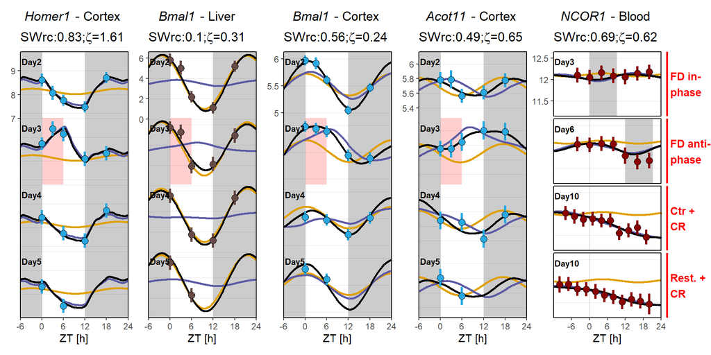

```r
homer1_c<-RemoveYlab(homer1_c)+ggtitle(bquote(atop(paste(italic("Homer1")," - Cortex"),paste("SWrc:",.(SWrc_homer1c),";",zeta,"=",.(zeta_c["Homer1"])))))
pbmal_c<-RemoveYlab(pbmal_c)+ggtitle(bquote(atop(paste(italic("Bmal1")," - Cortex"),paste("SWrc:",.(SWrc_pbmal_c),";",zeta,"=",.(zeta_c["Arntl"])))))
pbmal_l<-RemoveYlab(pbmal_l)+ggtitle(bquote(atop(paste(italic("Bmal1")," - Liver"),paste("SWrc:",.(SWrc_pbmal_l),";",zeta,"=",.(zeta_l["Arntl"])))))
pacot_c<-RemoveYlab(pacot_c)+ggtitle(bquote(atop(paste(italic("Acot11")," - Cortex"),paste("SWrc:",.(SWrc_pacot_c),";",zeta,"=",.(zeta_c["Acot11"])))))
pncor1_sync<-RemoveYlab(pncor1_sync)+ggtitle(bquote(atop(paste(italic("NCOR1")," - Blood"),paste("SWrc:",.(SWrc_NCOR1),";",zeta,"=",.(zeta_h["A_24_P204214"])))))


ggF<-homer1_c|pbmal_l|pbmal_c|pacot_c|(pncor1_sync/pncor1_desync/pncor1_ctr/pncor1_res)
ggF
```

```r
ggsave(paste(FIGUREDIR,"ExampleGeneExpression_Withfits.pdf",sep=""), width = 200*1.2, height = 150*1.2, units = "mm",plot = ggF)
```

# Clock

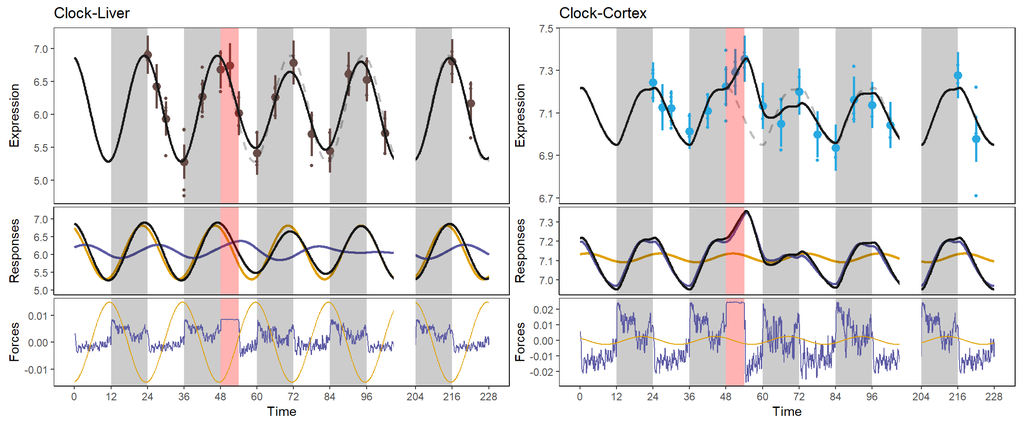

```r
source(RASTERPLOT_FUN)
Gene<-"Clock"
ggclock_l<-PlotMouseFit(Gene,"Liver",ASContribution = F,bsldashed = T)
ggclock_l_resp<-PlotMouseFit(Gene,"Liver",ASContribution = T,bsldashed = T)
ggclock_c<-PlotMouseFit(Gene,"Cortex",ASContribution = F,bsldashed = T)
ggclock_C_resp<-PlotMouseFit(Gene,"Cortex",ASContribution = T,bsldashed = T)

ggclock_l<-RemoveXaxis(ggclock_l)+ggtitle(paste(Gene,"-Liver",sep=""))+ylab("Expression")+theme(plot.margin = margin(0,0,0,0))
ggclock_c<-RemoveXaxis(ggclock_c)+ggtitle(paste(Gene,"-Cortex",sep=""))+ylab("Expression")+theme(plot.margin = margin(0,0,0,0))
ggclock_C_resp<-RemoveXaxis(ggclock_C_resp)+ggtitle(NULL)+theme(plot.margin = margin(0,0,0,0))
ggclock_l_resp<-RemoveXaxis(ggclock_l_resp)+ggtitle(NULL)+theme(plot.margin = margin(0,0,0,0))

ggclock_l_force<-PlotForces(Gene,"Liver")+theme(plot.margin = margin(0,2,2,2))
ggclock_c_force<-PlotForces(Gene,"Cortex")+theme(plot.margin = margin(0,2,2,2))

layout <- '
AB
CD
EF
'

# Force




ggF<-wrap_plots(A=ggclock_l,B=ggclock_c,C=ggclock_l_resp,D=ggclock_C_resp,E=ggclock_l_force,"F"=ggclock_c_force, design = layout,heights = c(.5,.25,.25))
ggF
```

```r
ggsave(paste(FIGUREDIR,"ExampleClock.pdf",sep=""), width = 200*1.2, height = 80*1.2, units = "mm",plot = ggF)
```

SWrc

```r
round(GetSWrcMouse(Gene,swdmr_c,fits_c),2)
```

```
## Clock
##  0.84
```

```r
round(GetSWrcMouse(Gene,swdmr_l,fits_l),2)
```

```
## Clock
##   0.2
```

# Linear

## Plot data

Load dataset in mouse

```r
source(LINEARPLOT_FUN)
dataMouseCortex<-LOADMOUSE(Tissue="Cortex")
dataMouseLiver<-LOADMOUSE(Tissue="Liver")
```

A function to add a straight line between time-points, baseline is replicated

```r
AddFitMouse<-function(Gene,dataMouse){
  fitBSL<-MeanBSLfit(dataMouse$rna_expr,Gene,bsl = 48)
  fitRec<-MeanBSLfit(dataMouse$rna_expr,Gene,bsl = 120)
  fitBSL_rep<-MeanBSLfit_Rep(dataMouse$rna_expr[dataMouse$rna_expr$Time <= 120,],Gene,bsl = 48)
  fitRec2<-MeanBSLfit(dataMouse$rna_expr[dataMouse$rna_expr$Time > 120,],Gene,bsl = 222)
  fitBSL2<-MeanBSLfit_Rep(dataMouse$rna_expr[dataMouse$rna_expr$Time <= 222,],Gene,bsl = 48)
  fitBSL2$y1<-fitBSL2$y1[fitBSL2$time>102]
  fitBSL2$time<-fitBSL2$time[fitBSL2$time>102]
  addfits<-list(fitBSL,fitBSL_rep,fitRec,fitRec2,fitBSL2)
  return(addfits)
}
colorf<-c("black","grey25","black","grey25","black");ltys<-c("solid","42","solid","solid","42")
```

Shows Homer1, Bmal1 and Acot11

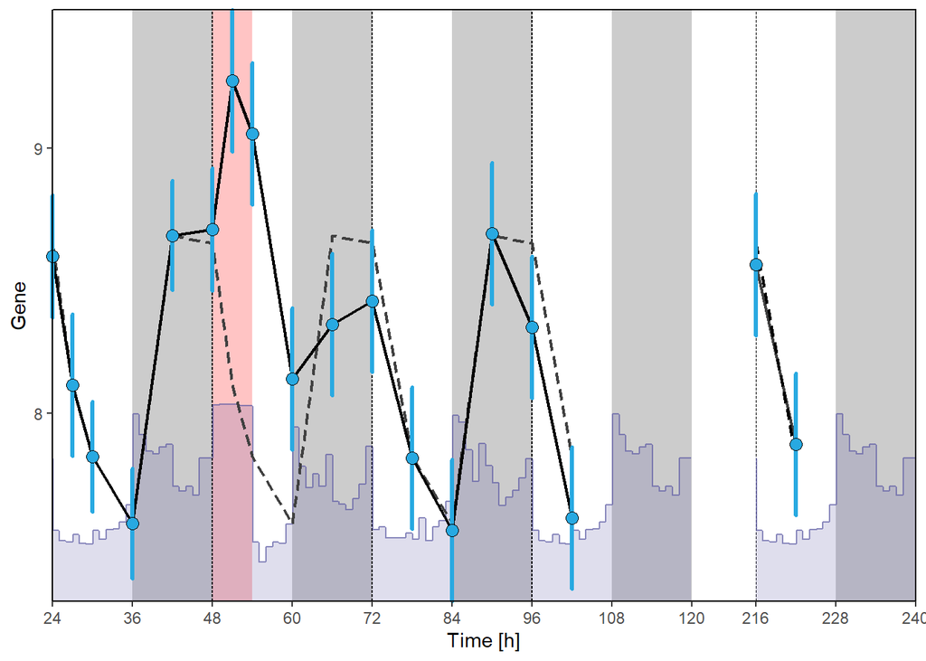

```r
source(LINEARPLOT_FUN)
Homer1_c<-LinearPlot(ProbeGene = "Homer1",Dataset = "Cortex",DaysShows = c(2,3,4,5,10),MeanPointSize = 3,npretty = 2,ModelFitLine = 0,
                    AddFits = AddFitMouse("Homer1",dataMouseCortex),ColsAddFits = colorf,LtyAddFits = ltys,AddSleepWake = T)
Homer1_c
```

```r
Homer1_c<-LinearPlot(ProbeGene = "Homer1",Dataset = "Cortex",DaysShows = c(1,2,3,4,5,10),MeanPointSize = 3,npretty = 2,ModelFitLine = 0,
                    AddFits = AddFitMouse("Homer1",dataMouseCortex),ColsAddFits = colorf,LtyAddFits = ltys,AddSleepWake = T)+coord_cartesian(xlim=c(24,230))
```

```
## replace the existing one.
```

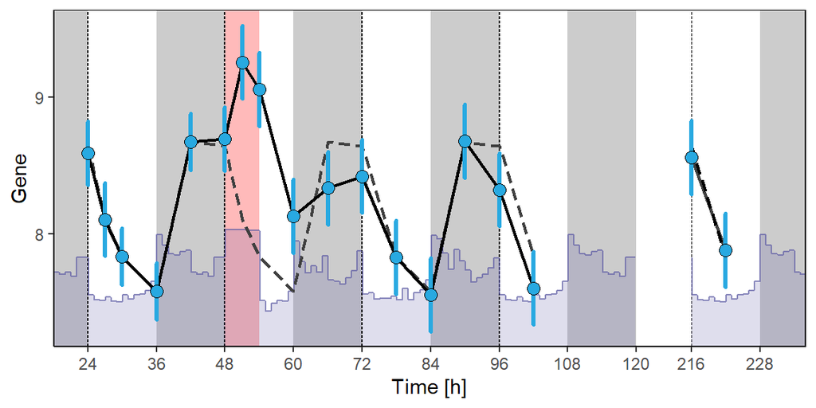

```r
Homer1_c
```

```r
pbmal_c<-LinearPlot(ProbeGene = "Arntl",Dataset = "Cortex",DaysShows = c(1,2,3,4,5,10),MeanPointSize = 3,npretty = 2,ModelFitLine = 0,
                    AddFits = AddFitMouse("Arntl",dataMouseCortex),ColsAddFits = colorf,LtyAddFits = ltys,AddSleepWake = T)+coord_cartesian(xlim=c(24,230))
```

```
## replace the existing one.
```

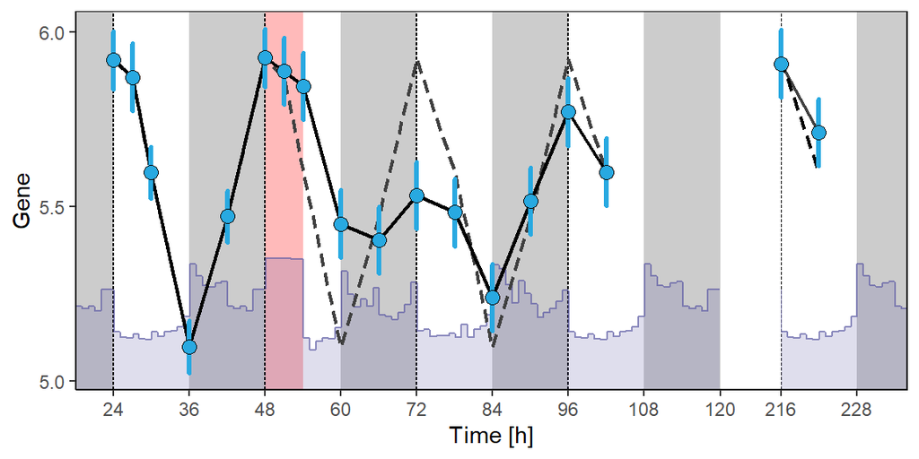

```r
pbmal_c
```

```r
pbmal_l<-LinearPlot(ProbeGene = "Arntl",Dataset = "Liver",DaysShows = c(1,2,3,4,5,10),MeanPointSize = 3,npretty = 2,ModelFitLine = 0,
                    AddFits = AddFitMouse("Arntl",dataMouseLiver),ColsAddFits = colorf,LtyAddFits = ltys,AddSleepWake = T)+coord_cartesian(xlim=c(24,230))
```

```
## replace the existing one.
```

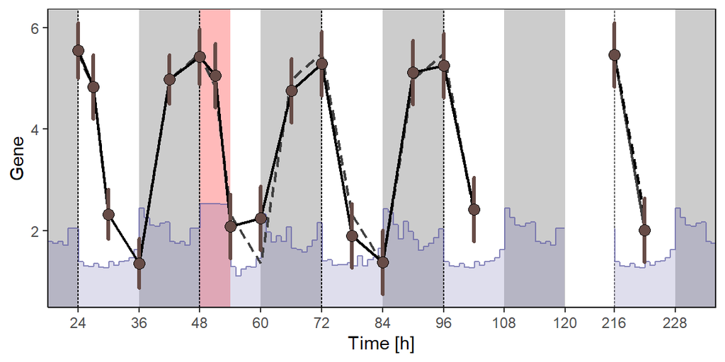

```r
pbmal_l
```

```r
pacot_c<-LinearPlot(ProbeGene = "Acot11",Dataset = "Cortex",DaysShows = c(1,2,3,4,5,10),MeanPointSize = 3,npretty = 2,ModelFitLine = 0,
                    AddFits = AddFitMouse("Acot11",dataMouseCortex),ColsAddFits = colorf,LtyAddFits = ltys,AddSleepWake = T)+coord_cartesian(xlim=c(24,230))
```

```
## replace the existing one.
```

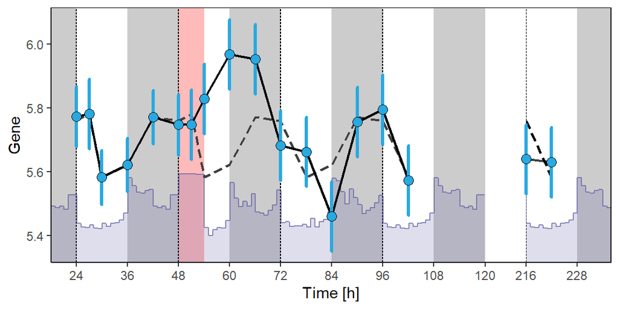

```r
pacot_c
```

Shows NCOR1 in human that decrease expression when sleeping in anti-phase, and decrease expression when awake during contant routine.

Load data

```r
dataHuman<-LOADHUMAN()
```

Function to add straight line between time-point in human

```r
AddFitHuman<-function(Gene,dataHumanExpr,EvalTime=NULL){
  fitBSL<-MeanBSLfit_Rep(dataHuman$HT_Desync,Gene,bsl = 67,EvalTime)
  fitRec<-MeanBSLfit(dataHumanExpr,Gene,bsl = 1e5)
  addfits<-list(fitBSL,fitRec)
  return(addfits)
}
```

```r
Range<-GetRangeExpressionHS("A_24_P204214")

pncor1_sync<-LinearPlot(ProbeGene = "A_24_P204214",Dataset = "Desync",DaysShows = c(2,3),MeanPointSize = 3,npretty = 3,ModelFitLine = 0,ylim=Range$ylim1,
                          AddFits = AddFitHuman("A_24_P204214",dataHuman$HT_Desync),ColsAddFits = c(rgb(0,0,0,0),"black"),LtyAddFits = c("42","solid"),AddSleepWake = T)+theme(plot.margin = margin(0,10,0,0))+coord_cartesian(xlim  = c(42,72),ylim=Range$ylim1)+ggtitle("FD in-phase")
```

```
## Intercept:12.0880497792636
```

```
## replace the existing one.
```

```r
pncor1_desync<-LinearPlot(ProbeGene = "A_24_P204214",Dataset = "Desync",DaysShows = c(5,6),MeanPointSize = 3,npretty = 2,ModelFitLine = 0,ylim=Range$ylim1,
                          AddFits = AddFitHuman("A_24_P204214",dataHuman$HT_Desync),ColsAddFits = c("grey25","black"),LtyAddFits = c("42","solid"),AddSleepWake = T)+
  theme(plot.margin = margin(0,10,0,0))+coord_cartesian(xlim  = c(114,144),ylim=Range$ylim1)+ggtitle("FD anti-phase")
```

```
## Intercept:12.0880497792636
## replace the existing one.
```

```r
pncor1_ctr<-LinearPlot(ProbeGene = "A_24_P204214",Dataset = "Ctr",DaysShows = c(9,10),MeanPointSize = 3,npretty = 2,ModelFitLine = 0,ylim=Range$ylim1,
                          AddFits = AddFitHuman("A_24_P204214",dataHuman$HT_Ext,EvalTime = seq(208,235,by=4)),ColsAddFits = c("grey25","black"),LtyAddFits = c("42","solid"),AddSleepWake = T)+theme(plot.margin = margin(0,10,0,0))+coord_cartesian(xlim  = c(202,240),ylim=Range$ylim1)+ggtitle("10h sleep + CR")
```

```
## Intercept:11.9980329052714
```

```
## [1] 9
## [1] 10
```

```
## replace the existing one.
```

```r
pncor1_res<-LinearPlot(ProbeGene = "A_24_P204214",Dataset = "Res",DaysShows = c(9,10),MeanPointSize = 3,npretty = 2,ModelFitLine = 0,ylim=Range$ylim1,
                          AddFits = AddFitHuman("A_24_P204214",dataHuman$HT_Res,EvalTime = seq(208,235,by=4)),ColsAddFits = c("grey25","black"),LtyAddFits = c("42","solid"),AddSleepWake = T)+theme(plot.margin = margin(0,10,0,0))+coord_cartesian(xlim  = c(202,240),ylim=Range$ylim1)+ggtitle("6h sleep + CR")
```

```
## Intercept:11.9980329052714
```

```
## [1] 9
## [1] 10
```

```
## replace the existing one.
```

```r
ggF<-pncor1_sync |
RemoveYaxis(pncor1_desync) |
(pncor1_ctr) |
RemoveYaxis(pncor1_res)
```

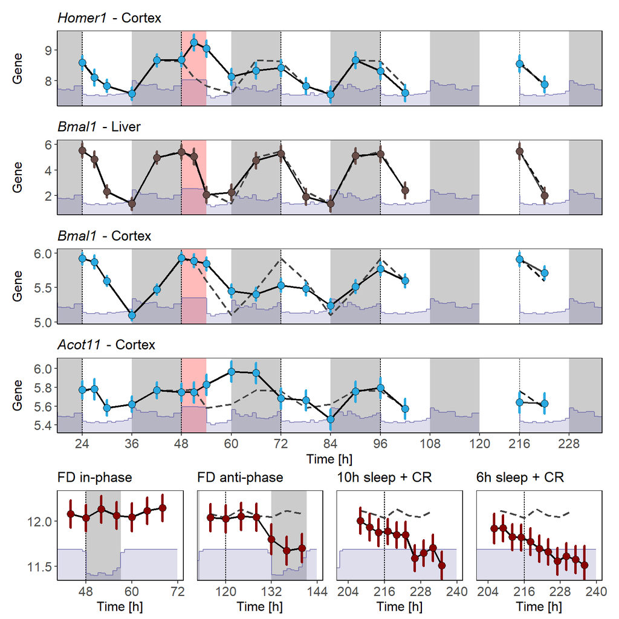

```r
Homer1_c<-RemoveXaxis(Homer1_c)+ggtitle(substitute(paste(italic("Homer1")," - Cortex")))
pbmal_c<-RemoveXaxis(pbmal_c)+ggtitle(substitute(paste(italic("Bmal1")," - Cortex")))
pbmal_l<-RemoveXaxis(pbmal_l)+ggtitle(substitute(paste(italic("Bmal1")," - Liver")))
pacot_c<-pacot_c+ggtitle(substitute(paste(italic("Acot11")," - Cortex")))
pncor1_sync<-RemoveYlab(pncor1_sync)#+ggtitle(substitute(paste(italic("NCOR1")," - Blood","\nIn-phase")))


Homer1_c<-Homer1_c+ theme(axis.text = element_text(size = 12),axis.title = element_text(size = 12))
pbmal_c<-pbmal_c+ theme(axis.text = element_text(size = 12),axis.title = element_text(size = 12))
pbmal_l<-pbmal_l+ theme(axis.text = element_text(size = 12),axis.title = element_text(size = 12))
pacot_c<-pacot_c+ theme(axis.text = element_text(size = 12),axis.title = element_text(size = 12))
pncor1_sync<-pncor1_sync+ theme(axis.text = element_text(size = 12),axis.title = element_text(size = 12))
pncor1_desync<-pncor1_desync+ theme(axis.text = element_text(size = 12),axis.title = element_text(size = 12))
pncor1_ctr<-pncor1_ctr+ theme(axis.text = element_text(size = 12),axis.title = element_text(size = 12))
pncor1_res<-pncor1_res+ theme(axis.text = element_text(size = 12),axis.title = element_text(size = 12))

HP<-(pncor1_sync|RemoveYaxis(pncor1_desync)|RemoveYaxis(pncor1_ctr)|RemoveYaxis(pncor1_res))
HP<-HP+plot_annotation(title = )
ggF<-Homer1_c/pbmal_l/pbmal_c/pacot_c/(HP)+plot_layout(heights = c(1,1,1,1,1.2))
ggF
```

```r
ggsave(paste(FIGUREDIR,"ExampleGeneExpressionLinear.pdf",sep=""), width = 125*1.5, height = 150*1.5, units = "mm",plot = ggF)
```

## Plot data with fits

Shows Homer1, Bmal1 and Acot11

```r
source(LINEARPLOT_FUN)
Homer1_c<-LinearPlot(ProbeGene = "Homer1",Dataset = "Cortex",DaysShows = c(2,3,4,5,10),MeanPointSize = 3,npretty = 2,ModelFitLine = 1,AddSleepWake = T,AddASkeldonSol = T)+coord_cartesian(xlim=c(18,240))
```

```
## replace the existing one.
```

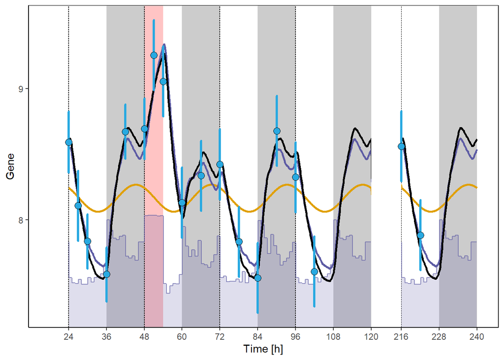

```r
Homer1_c
```

```r
Homer1_c<-LinearPlot(ProbeGene = "Homer1",Dataset = "Cortex",DaysShows = c(1,2,3,4,5,10),MeanPointSize = 3,npretty = 2,ModelFitLine = 1,AddSleepWake = T,AddASkeldonSol = T)+coord_cartesian(xlim=c(24,230))
```

```
## replace the existing one.
```

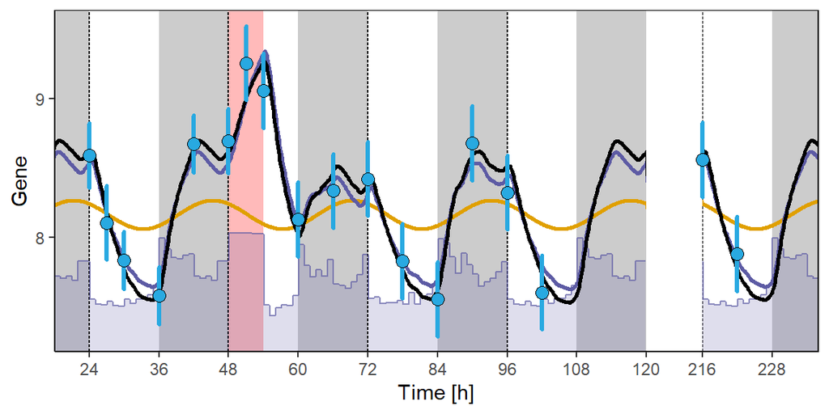

```r
Homer1_c
```

```r
pbmal_c<-LinearPlot(ProbeGene = "Arntl",Dataset = "Cortex",DaysShows = c(1,2,3,4,5,10),MeanPointSize = 3,npretty = 2,ModelFitLine = 1,AddSleepWake = T,AddASkeldonSol = T)+coord_cartesian(xlim=c(24,230))
```

```
## replace the existing one.
```

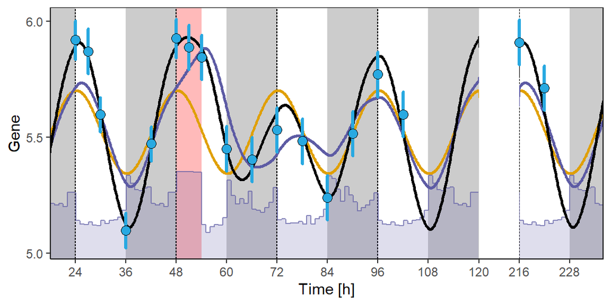

```r
pbmal_c
```

```r
pbmal_l<-LinearPlot(ProbeGene = "Arntl",Dataset = "Liver",DaysShows = c(1,2,3,4,5,10),MeanPointSize = 3,npretty = 2,ModelFitLine = 1,AddSleepWake = T,AddASkeldonSol = T)+coord_cartesian(xlim=c(24,230))
```

```
## replace the existing one.
```

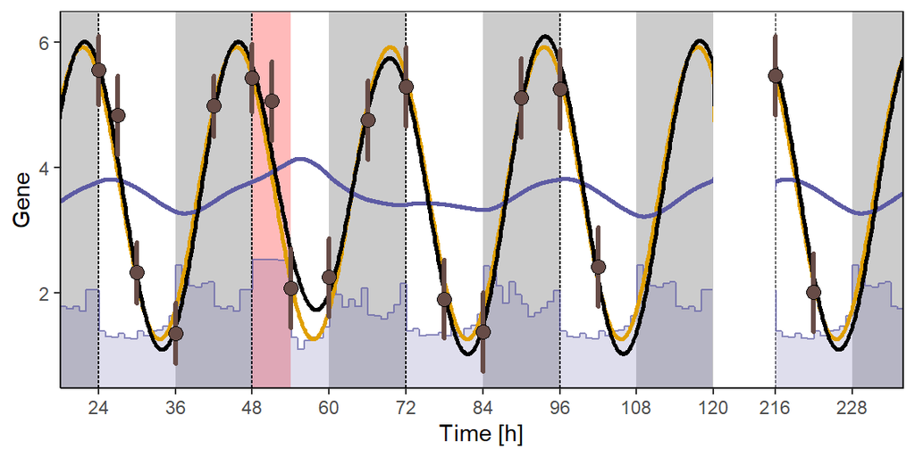

```r
pbmal_l
```

```r
pacot_c<-LinearPlot(ProbeGene = "Acot11",Dataset = "Cortex",DaysShows = c(1,2,3,4,5,10),MeanPointSize = 3,npretty = 2,ModelFitLine = 1,AddSleepWake = T,AddASkeldonSol = T)+coord_cartesian(xlim=c(24,230))
```

```
## replace the existing one.
```

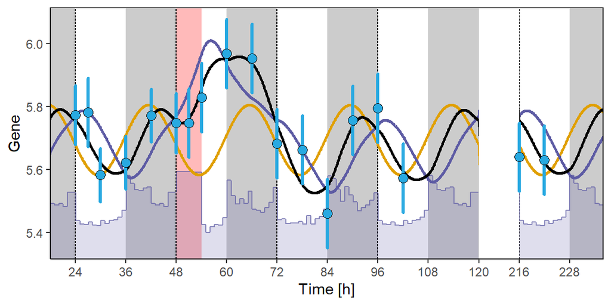

```r
pacot_c
```

Shows NCOR1 in human that decrease expression when sleeping in anti-phase, and decrease expression when awake during contant routine.

Load data

```r
dataHuman<-LOADHUMAN()
```

```r
Range<-GetRangeExpressionHS("A_24_P204214")

pncor1_sync<-LinearPlot(ProbeGene = "A_24_P204214",Dataset = "Desync",DaysShows = c(2,3),MeanPointSize = 3,npretty = 3,ModelFitLine = 1,ylim=Range$ylim1,AddSleepWake = T,AddASkeldonSol = T)+theme(plot.margin = margin(0,10,0,0))+coord_cartesian(xlim  = c(42,72),ylim=Range$ylim1)+ggtitle("FD in-phase")
```

```
## Intercept:12.0880497792636
```

```
## replace the existing one.
```

```r
pncor1_desync<-LinearPlot(ProbeGene = "A_24_P204214",Dataset = "Desync",DaysShows = c(5,6),MeanPointSize = 3,npretty = 3,ModelFitLine = 1,ylim=Range$ylim1,AddSleepWake = T,AddASkeldonSol = T)+
  theme(plot.margin = margin(0,10,0,0))+coord_cartesian(xlim  = c(114,144),ylim=Range$ylim1)+ggtitle("FD anti-phase")
```

```
## Intercept:12.0880497792636
## replace the existing one.
```

```r
pncor1_ctr<-LinearPlot(ProbeGene = "A_24_P204214",Dataset = "Ctr",DaysShows = c(9,10),MeanPointSize = 3,npretty = 3,ModelFitLine = 1,ylim=Range$ylim2,AddSleepWake = T,AddASkeldonSol = T)+theme(plot.margin = margin(0,10,0,0))+coord_cartesian(xlim  = c(202,240),ylim=Range$ylim2)+ggtitle("10h sleep + CR")
```

```
## Intercept:11.9980329052714
```

```
## [1] 9
## [1] 10
```

```
## replace the existing one.
```

```r
pncor1_res<-LinearPlot(ProbeGene = "A_24_P204214",Dataset = "Res",MeanPointSize = 3,npretty = 3,ModelFitLine = 1,ylim=Range$ylim2,AddSleepWake = T,AddASkeldonSol = T)+theme(plot.margin = margin(0,10,0,0))+coord_cartesian(xlim  = c(202,240),ylim=Range$ylim2)+ggtitle("6h sleep + CR")
```

```
## Intercept:11.9980329052714
```

```
## [1] 1
## [1] 2
## [1] 3
## [1] 4
## [1] 5
## [1] 6
## [1] 7
## [1] 8
## [1] 9
## [1] 10
```

```
## replace the existing one.
```

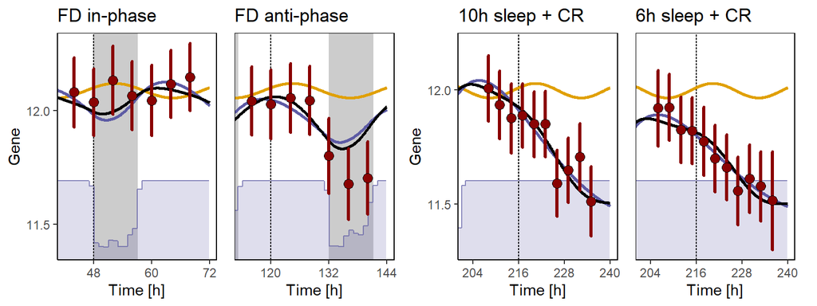

```r
ggF<-pncor1_sync |
RemoveYaxis(pncor1_desync) |
(pncor1_ctr) |
RemoveYaxis(pncor1_res)
ggF
```

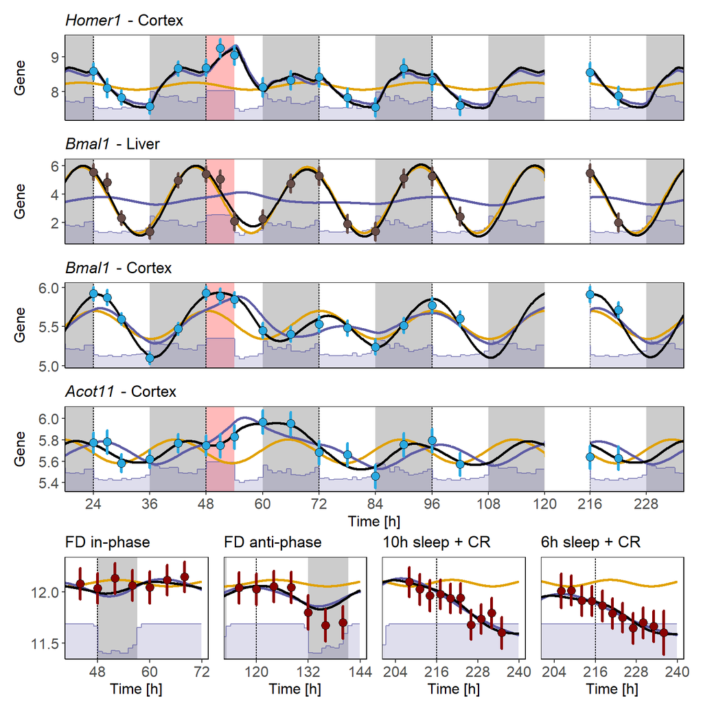

```r
Homer1_c<-RemoveXaxis(Homer1_c)+ggtitle(substitute(paste(italic("Homer1")," - Cortex")))
pbmal_c<-RemoveXaxis(pbmal_c)+ggtitle(substitute(paste(italic("Bmal1")," - Cortex")))
pbmal_l<-RemoveXaxis(pbmal_l)+ggtitle(substitute(paste(italic("Bmal1")," - Liver")))
pacot_c<-pacot_c+ggtitle(substitute(paste(italic("Acot11")," - Cortex")))
pncor1_sync<-RemoveYlab(pncor1_sync)#+ggtitle(substitute(paste(italic("NCOR1")," - Blood","\nIn-phase")))


Homer1_c<-Homer1_c+ theme(axis.text = element_text(size = 12),axis.title = element_text(size = 12))
pbmal_c<-pbmal_c+ theme(axis.text = element_text(size = 12),axis.title = element_text(size = 12))
pbmal_l<-pbmal_l+ theme(axis.text = element_text(size = 12),axis.title = element_text(size = 12))
pacot_c<-pacot_c+ theme(axis.text = element_text(size = 12),axis.title = element_text(size = 12))
pncor1_sync<-pncor1_sync+ theme(axis.text = element_text(size = 12),axis.title = element_text(size = 12))
pncor1_desync<-pncor1_desync+ theme(axis.text = element_text(size = 12),axis.title = element_text(size = 12))
pncor1_ctr<-pncor1_ctr+ theme(axis.text = element_text(size = 12),axis.title = element_text(size = 12))
pncor1_res<-pncor1_res+ theme(axis.text = element_text(size = 12),axis.title = element_text(size = 12))

HP<-(pncor1_sync|RemoveYaxis(pncor1_desync)|RemoveYaxis(pncor1_ctr)|RemoveYaxis(pncor1_res))
HP<-HP+plot_annotation(title = )
ggF<-Homer1_c/pbmal_l/pbmal_c/pacot_c/(HP)+plot_layout(heights = c(1,1,1,1,1.2))
ggF
```

```r
# ggsave(paste(FIGUREDIR,"ExampleGeneExpressionLinear.pdf",sep=""), width = 200*1.2, height = 160*1.2, units = "mm",plot = ggF)
```

Get SWrc

```r
swdmr_c<-SWDMr(dataMouseCortex$SWdf,dataMouseCortex$rna_expr)
fits_c<-read.table(CORTEXFITS,header=T)
SWrc_homer1c<-round(GetSWrcMouse("Homer1",swdmr_c,fits_c),2)
SWrc_pbmal_c<-round(GetSWrcMouse("Arntl",swdmr_c,fits_c),2)
SWrc_pacot_c<-round(GetSWrcMouse("Acot11",swdmr_c,fits_c),2)

swdmr_l<-SWDMr(dataMouseLiver$SWdf,dataMouseLiver$rna_expr)
fits_l<-read.table(LIVERFITS,header=T)
SWrc_pbmal_l<-round(GetSWrcMouse("Arntl",swdmr_l,fits_l),2)

fits_h<-read.table(HUMANFITS,header=T)
SWrc_NCOR1<-round(GetSWrcHuman("A_24_P204214",dataHuman$MeanSWdf,dataHuman$HT_Desync,fits_h),2)

round(GetSWrcHuman(ProbeIDs = "A_24_P204214",SWdf_human = dataHuman$MeanSWdfExt,HT_Desync = dataHuman$HT_Desync,fits = fits_h,AfterCR = T),3)
```

```
## A_24_P204214
##        0.897
```

```r
round(GetSWrcHuman(ProbeIDs = "A_24_P204214",SWdf_human = dataHuman$MeanSWdfRest,HT_Desync = dataHuman$HT_Desync,fits = fits_h,AfterCR = T),3)
```

```
## A_24_P204214
##        0.899
```

```r
GetZeta<-function(fits,Genes){
  if ("ProbeName" %in% colnames(fits)){
    fits<-fits[fits$ProbeName %in% Genes,]
    zetas<-exp(fits$loggamma)/(2*fits$omega)
    names(zetas)<-fits$ProbeName
  }else{
    fits<-fits[fits$Gene %in% Genes,]
    zetas<-exp(fits$loggamma)/(2*fits$omega)
    names(zetas)<-fits$Gene
  }
  return(zetas)
}

zeta_c<-round(GetZeta(fits_c,c("Arntl","Acot11","Homer1","Clock")),2)
zeta_l<-round(GetZeta(fits_l,c("Arntl","Clock")),2)
zeta_h<-round(GetZeta(fits_h,c("A_24_P204214")),2)
```

```r
round(Gettau(c("Arntl","Acot11","Homer1","Clock"),fits_c),2)
```

```
##  Arntl Acot11 Homer1  Clock
##  19.26  10.82   5.47   4.68
```

```r
round(Gettau(c("Arntl","Clock"),fits_l),2)
```

```
## Arntl Clock
## 16.73 78.82
```

```r
round(Gettau(c("A_24_P204214"),fits_h),2)
```

```
## A_24_P204214
##         20.8
```

```r
round(GetPhaseLag(c("Arntl","Acot11","Homer1","Clock"),fits_c,PosAmp = T),2)
```

```
##  Arntl Acot11 Homer1  Clock
##   2.27   2.35   1.13   1.52
```

```r
round(GetPhaseLag(c("Arntl","Clock"),fits_l,PosAmp = T),2)
```

```
## Arntl Clock
##  2.37  2.80
```

```r
round(GetPhaseLag(c("A_24_P204214"),fits_h,PosAmp = T),2)
```

```
## A_24_P204214
##         2.76
```

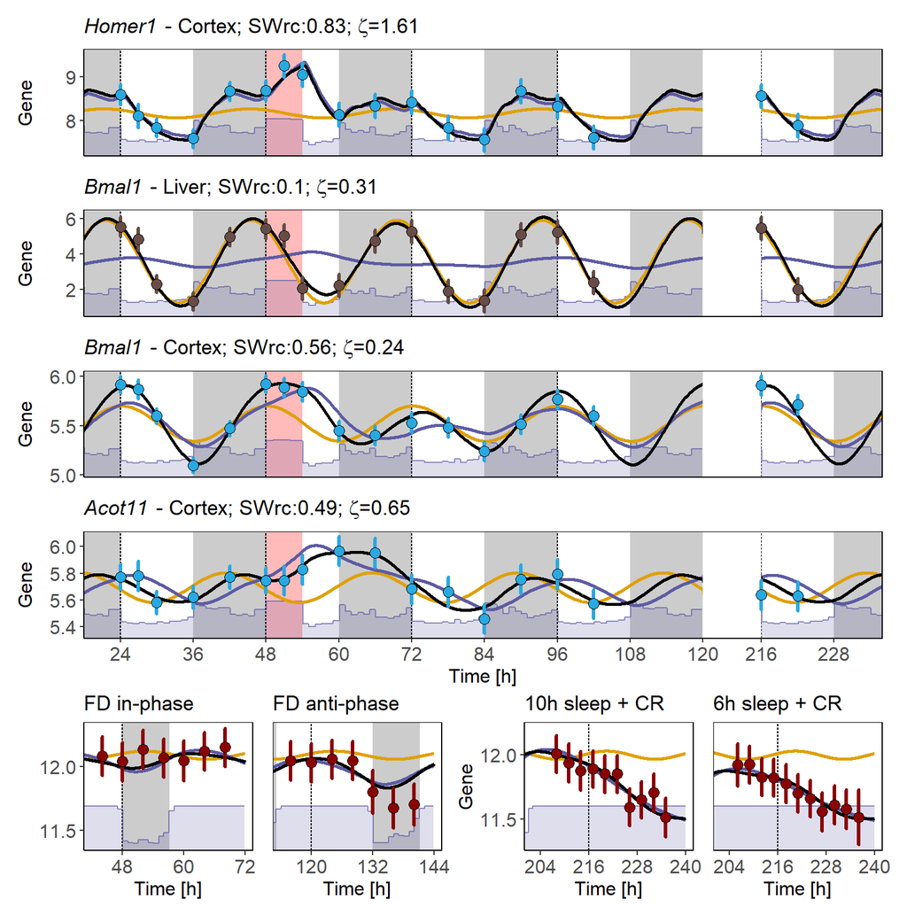

```r
Homer1_c<-Homer1_c+ggtitle(bquote(paste(paste(italic("Homer1")," - Cortex"),paste("; SWrc:",.(SWrc_homer1c),"; ",zeta,"=",.(zeta_c["Homer1"])))))
pbmal_c<-pbmal_c+ggtitle(bquote(paste(paste(italic("Bmal1")," - Cortex"),paste("; SWrc:",.(SWrc_pbmal_c),"; ",zeta,"=",.(zeta_c["Arntl"])))))
pbmal_l<-pbmal_l+ggtitle(bquote(paste(paste(italic("Bmal1")," - Liver"),paste("; SWrc:",.(SWrc_pbmal_l),"; ",zeta,"=",.(zeta_l["Arntl"])))))
pacot_c<-pacot_c+ggtitle(bquote(paste(paste(italic("Acot11")," - Cortex"),paste("; SWrc:",.(SWrc_pacot_c),"; ",zeta,"=",.(zeta_c["Acot11"])))))

# pncor1_sync<-pncor1_sync+ggtitle(bquote(atop(paste(italic("NCOR1")," - Blood"),paste("SWrc:",.(SWrc_NCOR1),";",zeta,"=",.(zeta_h["A_24_P204214"])))))

HP<-(pncor1_sync|RemoveYaxis(pncor1_desync)|(pncor1_ctr)|RemoveYaxis(pncor1_res))
HP<-HP+plot_annotation(title = )
ggF<-Homer1_c/pbmal_l/pbmal_c/pacot_c/(HP)+plot_layout(heights = c(1,1,1,1,1.2))
ggF
```

```r
ggsave(paste(FIGUREDIR,"ExampleGeneExpressionLinear_Withfits.pdf",sep=""), width = 125*1.5, height = 150*1.5, units = "mm",plot = ggF)
```